# SitAn Togo — infographies UNICEF

Prototype reproductible - Support de la note démonstration

R

UNICEF

SitAN

Togo

Rapport & Note

Notebook type , support de code et de calculs pour la note de démonstration SitAn-Togo - Candidature Unicef.

Published

March 20, 2026

# 1 Préambule et setup

Cette note analytique de démonstration est un exercice préparatoire — **non un livrable de la SitAn** — produit à l’appui de la candidature à la consultance internationale *Analyse de Situation des enfants et adolescents au Togo* (Réf. 592290, UNICEF Togo).

Elle illustre la manière dont je propose de traiter l’axe « **digitalisation comme facteur transversal** » imposé par les termes de référence : non comme un thème additionnel, mais comme un **analyseur transversal des inégalités, des risques et des opportunités** pour les enfants et adolescent·es togolais.

Le notebook est volontairement structuré pour servir de **dictionnaire d’indicateurs minimal**, avec traçabilité complète des sources, des proxys et des limites. Cette discipline anticipe les exigences de conformité méthodologique et de reproductibilité attendues par UNICEF.

**Reproductibilité**

```r
suppressPackageStartupMessages({
  library(tidyverse)   # dplyr, tibble, ggplot2, readr
  library(ggplot2)
  library(ggtext)      # markdown dans labels ggplot
  library(patchwork)   # composition d'infographies
  library(scales)      # formatage axes
  library(here)        # chemins de fichiers portables
  library(systemfonts) # gestion des polices système
})

qmd_file <- tryCatch(knitr::current_input(), error = function(e) NULL)
root_dir <- if (!is.null(qmd_file)) dirname(normalizePath(qmd_file)) else getwd()
data_dir <- file.path(root_dir, "data_sitan_togo")
output_dir <- file.path(root_dir, "output")
dir.create(output_dir, showWarnings = FALSE, recursive = TRUE)


# --- Chargement du thème maison (charte UNICEF / SitAn) ----------------------
source(here::here("projects", "SitAn-Togo", "R", "theme_sitan.R"))

# ---------- palette UNICEF (alternative, fallback)----------

pal <- list(
  blue       = "#1CABE2",
  dark_blue  = "#0077A3",
  light_blue = "#EAF8FD",
  orange     = "#F26A21",
  yellow     = "#F7B500",
  red        = "#D71920",
  green      = "#2EB67D",
  purple     = "#7B61FF",
  pink       = "#E91E8C",
  gray       = "#6D7278",
  light_gray = "#F2F4F5",
  dark       = "#222222"
)

accent_values <- c(
  blue      = pal$blue,
  orange    = pal$orange,
  green     = pal$green,
  red       = pal$red,
  purple    = pal$purple,
  yellow    = pal$yellow,
  dark_blue = pal$dark_blue,
  pink      = pal$pink
)

# ---------- thèmes ----------

theme_unicef <- function(base_size = 11, base_family = "sans") {
  theme_minimal(base_size = base_size, base_family = base_family) +
    theme(
      plot.title       = element_text(face = "bold", colour = pal$blue, size = rel(1.15)),
      plot.subtitle    = element_text(colour = pal$gray, size = rel(.92)),
      plot.caption     = element_text(colour = pal$gray, size = rel(.72), hjust = 0),
      axis.title       = element_text(colour = pal$gray),
      axis.text        = element_text(colour = pal$dark),
      panel.grid.minor = element_blank(),
      panel.grid.major.y = element_blank(),
      legend.position  = "none",
      plot.margin      = margin(8, 8, 8, 8)
    )
}

theme_set(theme_unicef())

theme_fun <- function(base_size = 11, base_family = "sans") {
  theme_void(base_size = base_size, base_family = base_family) +
    theme(
      plot.title    = element_text(face = "bold", colour = pal$blue,
                                   size = rel(1.25), margin = margin(b = 4)),
      plot.subtitle = element_text(colour = pal$gray,
                                   size = rel(.95), margin = margin(b = 8)),
      plot.caption  = element_text(colour = pal$gray, size = rel(.70),
                                   hjust = 0, margin = margin(t = 8)),
      plot.margin   = margin(8, 8, 8, 8)
    )
}


# --- Police par défaut : DejaVu Sans (dispo Linux/macOS, fallback sur 'sans') -
base_family_default <- if ("DejaVu Sans" %in% system_fonts()$family) {
  "DejaVu Sans"
} else {
  "sans"
}

# Forcer la famille sur tous les geoms texte et sur le thème global
update_geom_defaults("text",  list(family = base_family_default))
update_geom_defaults("label", list(family = base_family_default))
theme_set(theme_sitan(base_family = base_family_default))


# ---------- helpers de formatage ----------

fmt_val <- function(x, unite = "%") {
  case_when(
    unite == "%" ~
      paste0(
        str_replace(
          format(round(x, 1), decimal.mark = ",", trim = TRUE),
          "\\.0$", ""
        ),
        "%"
      ),
    unite == "\u2030 naissances vivantes" ~
      paste0(
        str_replace(
          format(round(x, 1), decimal.mark = ",", trim = TRUE),
          "\\.0$", ""
        ),
        "\u2030"
      ),
    unite == "n" & x < 1 ~
      format(round(x, 3), decimal.mark = ",", trim = TRUE),
    unite == "n" ~
      format(round(x, 0), big.mark = "\u202f", decimal.mark = ",", trim = TRUE),
    TRUE ~
      format(round(x, 1), big.mark = "\u202f", decimal.mark = ",", trim = TRUE)
  )
}

fr_num <- function(x, digits = 1) {
  out <- format(round(x, digits), big.mark = "\u202f", decimal.mark = ",", trim = TRUE)
  str_replace(out, ",0$", "")
}

fmt_pct_fr <- function(x) paste0(fr_num(x), "\u202f%")

# ---------- helper waffle ----------

waffle_100 <- function(value, title, subtitle = NULL, fill = pal$blue, caption = NULL) {
  grid <- tibble(i = 1:100) |>
    mutate(
      x  = ((i - 1) %% 10) + 1,
      y  = 11 - ceiling(i / 10),
      on = i <= round(value)
    )

  ggplot(grid, aes(x = x, y = y)) +
    geom_point(
      aes(fill = on), shape = 21, size = 3.7,
      colour = "white", stroke = 0.35
    ) +
    scale_fill_manual(
      values = c(`TRUE` = fill, `FALSE` = pal$light_gray),
      guide  = "none"
    ) +
    coord_equal() +
    labs(title = title, subtitle = subtitle, caption = caption) +
    theme_fun() +
    theme(
      plot.title    = element_text(face = "bold", colour = fill, size = 16),
      plot.subtitle = element_text(colour = pal$dark, size = 10),
      plot.caption  = element_text(colour = pal$gray, size = 7, hjust = 0)
    )
}

# Forcer Cairo comme bitmap par défaut (antialiasing et UTF-8 propres)
options(bitmapType = "cairo")

# Dossier de sortie
dir.create(here::here("output"), showWarnings = FALSE, recursive = TRUE)
```

## 1.1 Données

```r
indicateurs      <- read_csv(file.path(data_dir, "00_indicateurs_cles_togo.csv"),
                             show_col_types = FALSE)
pauvrete         <- read_csv(file.path(data_dir, "01_pauvrete_enfants_togo.csv"),
                             show_col_types = FALSE)
education        <- read_csv(file.path(data_dir, "02_education_togo.csv"),
                             show_col_types = FALSE)
services         <- read_csv(file.path(data_dir, "03_services_risques_togo.csv"),
                             show_col_types = FALSE)
digital          <- read_csv(file.path(data_dir, "04_digitalisation_togo_officiel.csv"),
                             show_col_types = FALSE)
actions_digitales <- read_csv(file.path(data_dir, "05_actions_digitalisation_sitan.csv"),
                              show_col_types = FALSE)
```

## 1.2 Vérification environnement

```
R version : R version 4.4.1 (2024-06-14 ucrt)
```

```
Répertoire de travail : C:/Users/fmarting/Documents/Travail_Data/Portfolio/Francisco-MG.github.io/projects/SitAn-Togo
```

```
Fichiers de données détectés :
```

```
00_indicateurs_cles_togo.csv
  01_fracture_globale.csv
  01_pauvrete_enfants_togo.csv
  02_education_togo.csv
  02_inegalites_togo.csv
  03_services_risques_togo.csv
  03_wash_ecoles.csv
  04_digitalisation_togo_officiel.csv
  04_initiatives_timeline.csv
  05_actions_digitalisation_sitan.csv
  06_genre_digital_divide_togo.csv
```

# 2 Panneaux visuels

## 2.1 2.1 Bandeau « sept repères »

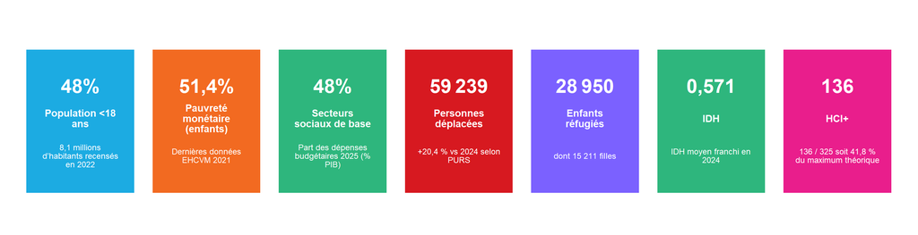

```r
# ---------- préparation des données ----------

df_cards <- indicateurs |>
  mutate(
    x = ordre,
    y = 1,
    valeur_txt = map2_chr(valeur, unite, fmt_val)

  )

# Dots pour les cartes en pourcentage
df_dots <- df_cards |>
  filter(unite == "%") |>
  tidyr::crossing(dot = 1:10) |>
  mutate(
    dot_x    = x - 0.31 + (dot - 1) * 0.069,
    dot_y    = 0.58,
    dot_fill = if_else(dot <= round(valeur / 10), "dot_on", "dot_off")
  )


# ---------- plot ----------

p_cards <- ggplot() +

  # Fond de chaque carte
  geom_tile(
    data = df_cards,
    aes(x = x, y = y, fill = accent),
    width = 0.88, height = 0.90,
    colour = "white", linewidth = 1.8
  ) +

  # Chiffre principal
  geom_text(
    data = df_cards,
    aes(x = x, y = 1.22, label = valeur_txt),
    colour = "white", fontface = "bold", size = 7.5,
    family = "sans"
  ) +

  # Nom de l'indicateur
  geom_text(
    data = df_cards,
    aes(x = x, y = 1.02, label = str_wrap(indicateur, 15)),
    colour = "white", fontface = "bold", size = 3.8,
    lineheight = 0.88, family = "sans"
  ) +

  # Sous-titre contextuel
  geom_text(
    data = df_cards,
    aes(x = x, y = 0.79, label = str_wrap(sous_titre, 22)),
    colour = "white", size = 3.2,
    lineheight = 0.86, family = "sans"
  ) +

  # ---------- échelles ----------

  scale_fill_manual(
    values = c(
      accent_values,
      dot_on  = "white",
      dot_off = scales::alpha("white", 0.28)
    )
  ) +
  scale_colour_manual(values = accent_values) +
  scale_x_continuous(limits = c(0.42, 7.58), expand = c(0, 0)) +
  scale_y_continuous(limits = c(0.43, 1.48), expand = c(0, 0)) +

  # ---------- habillage ----------

  labs(
    title    = "",
    subtitle = "",
    caption  = paste(
      ""
    )
  ) +
  theme_fun() +
  theme(
    legend.position = "none",
    plot.title    = element_text(face = "bold", colour = pal$blue, size = 18),
    plot.subtitle = element_text(colour = pal$gray, size = 11),
    plot.caption  = element_text(hjust = 0.5, size = 7, lineheight = 1.1)
  )

p_cards
```

## 2.2 Pauvreté des enfants : mettre en scène l’écart rural/urbain

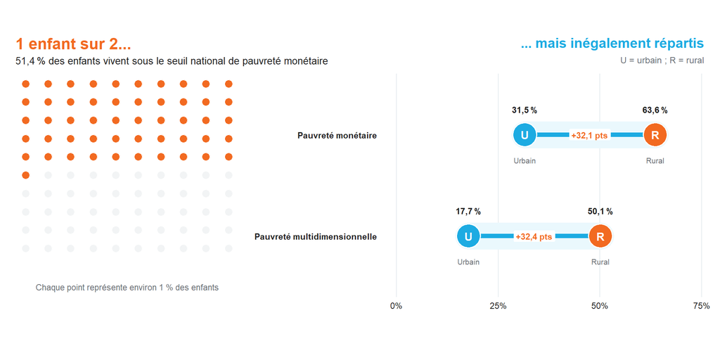

```r
pauv_nat <- pauvrete |>
  filter(indicateur == "Pauvret\u00e9 mon\u00e9taire", milieu == "National") |>
  pull(valeur) |>
  first()

df_pauv <- pauvrete |>
  filter(milieu %in% c("Urbain", "Rural")) |>
  mutate(
    indicateur = factor(indicateur, levels = rev(unique(indicateur))),
    milieu     = factor(milieu, levels = c("Urbain", "Rural"))
  )

df_gap <- df_pauv |>
  select(indicateur, milieu, valeur) |>
  pivot_wider(names_from = milieu, values_from = valeur) |>
  mutate(
    ecart       = Rural - Urbain,
    label_ecart = paste0("+", fr_num(ecart), " pts")
  )

p_pauv_waffle <- waffle_100(
  value    = pauv_nat,
  title    = "1 enfant sur 2...",
  subtitle = paste0(fmt_pct_fr(pauv_nat),
                    " des enfants vivent sous le seuil national de pauvret\u00e9 mon\u00e9taire"),
  fill     = pal$orange
) +
  annotate(
    "text", x = 5.5, y = -1.1,
    label  = "Chaque point repr\u00e9sente environ 1 % des enfants",
    colour = pal$gray, size = 3.0
  ) +
  coord_cartesian(clip = "off")

p_gap <- ggplot(df_pauv, aes(x = valeur, y = indicateur)) +
  geom_segment(
    data = df_gap,
    aes(x = Urbain, xend = Rural, y = indicateur, yend = indicateur),
    inherit.aes = FALSE,
    colour = pal$light_blue, linewidth = 13, lineend = "round"
  ) +
  geom_segment(
    data = df_gap,
    aes(x = Urbain, xend = Rural, y = indicateur, yend = indicateur),
    inherit.aes = FALSE,
    colour = pal$blue, linewidth = 2.2, lineend = "round"
  ) +
  geom_point(
    aes(fill = milieu),
    shape = 21, size = 11, colour = "white", stroke = 1
  ) +
  geom_text(
    aes(label = if_else(milieu == "Urbain", "U", "R")),
    colour = "white", fontface = "bold", size = 4, family = "sans"
  ) +
  geom_text(
    aes(label = fmt_pct_fr(valeur)),
    nudge_y = 0.25,
    colour = pal$dark, fontface = "bold", size = 3.1, family = "sans"
  ) +
  geom_text(
    aes(label = milieu),
    nudge_y = -0.25,
    colour = pal$gray, size = 2.8, family = "sans"
  ) +
  geom_label(
    data = df_gap,
    aes(x = (Urbain + Rural) / 2, y = indicateur, label = label_ecart),
    inherit.aes = FALSE,
    fill = "white", colour = pal$orange, fontface = "bold",
    label.size = 0, size = 3, family = "sans"
  ) +
  scale_fill_manual(values = c(Urbain = pal$blue, Rural = pal$orange)) +
  scale_x_continuous(
    limits = c(0, 72), breaks = c(0, 25, 50, 75),
    labels = label_percent(scale = 1)
  ) +
  labs(
    title    = "... mais inégalement répartis",
    subtitle = "U = urbain ; R = rural",
    x = NULL, y = NULL
  ) +
  theme_unicef() +
  theme(
    panel.grid.major.x = element_line(colour = "#E6ECEF"),
    axis.text.y    = element_text(face = "bold", colour = pal$dark),
    plot.title     = element_text(face = "bold", colour = pal$blue, size = 14, hjust = 1),
    plot.subtitle  = element_text(colour = pal$gray, size = 9, hjust = 1)
  )

p_poverty <- (p_pauv_waffle | p_gap) +
  plot_layout(widths = c(0.9, 1.3)) +
  plot_annotation(
    title   = "",
    caption = "",
    theme   = theme(
      plot.title   = element_text(face = "bold", colour = pal$blue, size = 15),
      plot.caption = element_text(colour = pal$gray, size = 7, hjust = 0)
    )
  )

p_poverty
```

## 2.3 Parcours éducatif : forte entrée, fragilité au secondaire

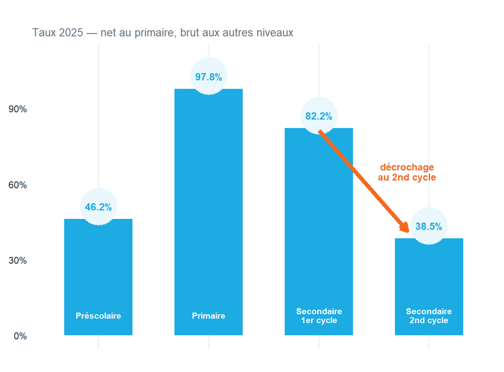

```r
df_freq <- education |>
  filter(domaine == "Fr\u00e9quentation") |>
  mutate(niveau = factor(niveau, levels = niveau))

df_freq <- education |>
  filter(domaine == "Fr\u00e9quentation") |>
  mutate(
    niveau = factor(niveau, levels = niveau),
    niveau_label = str_replace(niveau, "Secondaire ", "Secondaire\n")
  )

p_education <- ggplot(df_freq, aes(x = niveau, y = valeur)) +
  geom_col(fill = pal$blue, width = 0.62) +
  geom_point(aes(y = valeur + 5), size = 16, colour = pal$light_blue) +
  geom_text(
    aes(y = valeur + 5, label = paste0(round(valeur, 1), "%")),
    colour = pal$blue, fontface = "bold", size = 3.3, family = "sans"
  ) +
  geom_text(
    aes(label = niveau_label, y = 8),
    colour = "white", fontface = "bold", size = 2.8,
    lineheight = 0.85, family = "sans"
  ) +
  # Flèche orange entre les deux barres du secondaire
  annotate(
    "segment",
    x = 3, xend = 3.8,
    y = 81.2, yend = 41.5,
    colour = pal$orange, linewidth = 1.8,
    arrow = arrow(length = unit(0.25, "cm"), type = "closed")
  ) +

  # Message à côté de la flèche
  annotate(
    "text",
    x = 3.8, y = 65,
    label = "d\u00e9crochage\nau 2nd cycle",
    colour = pal$orange, fontface = "bold",
    size = 3.2, hjust = 0.5, lineheight = 0.85, family = "sans"
  ) +
  scale_y_continuous(limits = c(0, 110), labels = label_percent(scale = 1)) +
  labs(
    title    = "",
    subtitle = "Taux 2025 \u2014 net au primaire, brut aux autres niveaux",
    x = NULL, y = NULL,
    caption  = ""
  ) +
  theme_unicef() +
  theme(axis.text.x = element_blank())

p_education
```

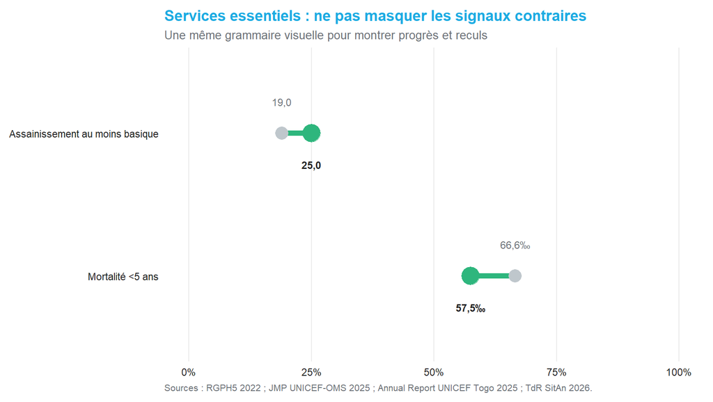

```r
df_slope <- services |>
  filter(indicateur %in% c(
    "D\u00e9f\u00e9cation \u00e0 l'air libre",
    "Assainissement au moins basique",
    "Acc\u00e8s \u00e0 l'eau potable",
    "Mortalit\u00e9 <5 ans"
  )) |>
  mutate(
    indicateur = factor(indicateur, levels = rev(indicateur)),
    better = case_when(
      sens == "down_good" & valeur < valeur_initiale ~ "am\u00e9lioration",
      sens == "up_good"   & valeur > valeur_initiale ~ "am\u00e9lioration",
      TRUE ~ "alerte"
    )
  )

p_wash <- ggplot(df_slope) +
  geom_segment(
    aes(x = valeur_initiale, xend = valeur,
        y = indicateur, yend = indicateur, colour = better),
    linewidth = 2.2, lineend = "round"
  ) +
  geom_point(
    aes(x = valeur_initiale, y = indicateur),
    colour = "#BFC7CC", size = 5
  ) +
  geom_point(
    aes(x = valeur, y = indicateur, colour = better),
    size = 7
  ) +
  geom_text(
    aes(x = valeur_initiale, y = indicateur,
        label = fmt_val(valeur_initiale, unite)),
    nudge_y = 0.22, colour = pal$gray, size = 3, family = "sans"
  ) +
  geom_text(
    aes(x = valeur, y = indicateur,
        label = fmt_val(valeur, unite)),
    nudge_y = -0.22, colour = pal$dark,
    fontface = "bold", size = 3, family = "sans"
  ) +
  scale_colour_manual(
    values = c("am\u00e9lioration" = pal$green, alerte = pal$orange)
  ) +
  scale_x_continuous(limits = c(0, 100), labels = label_percent(scale = 1)) +
  labs(
    title    = "Services essentiels : ne pas masquer les signaux contraires",
    subtitle = "Une m\u00eame grammaire visuelle pour montrer progr\u00e8s et reculs",
    x = NULL, y = NULL,
    caption  = "Sources : RGPH5 2022 ; JMP UNICEF-OMS 2025 ; Annual Report UNICEF Togo 2025 ; TdR SitAn 2026."
  ) +
  theme_unicef()

p_wash
```

## 2.5 Protection : cartes de risques

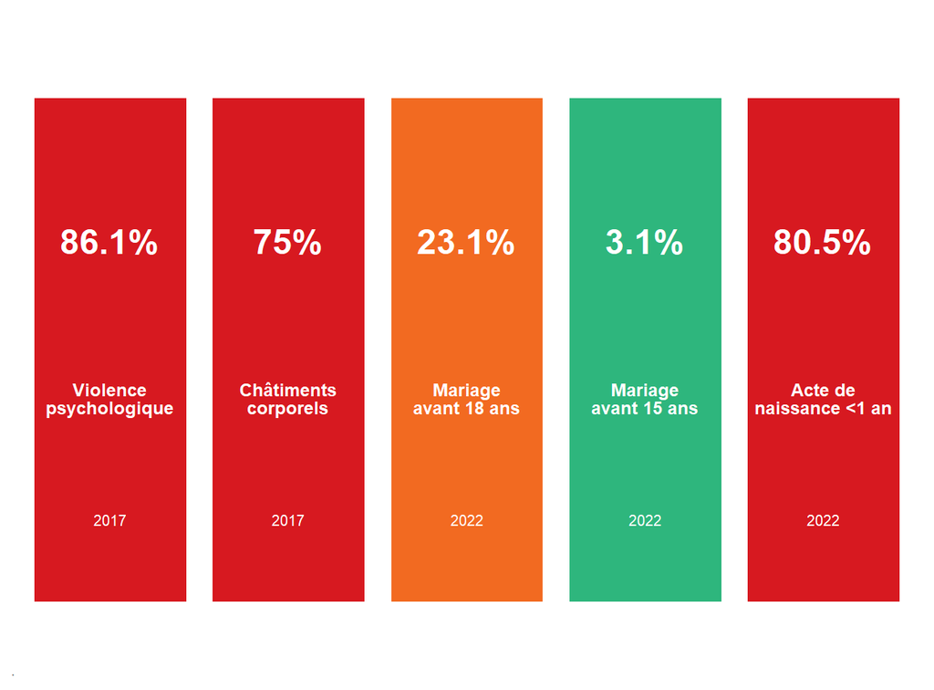

```r
df_prot <- services |>
  filter(domaine == "Protection") |>
  mutate(
    x      = row_number(),
    label  = paste0(round(valeur, 1), "%"),
    danger = case_when(
      valeur >= 70 ~ "critique",
      valeur >= 20 ~ "\u00e9lev\u00e9",
      TRUE         ~ "progr\u00e8s"
    )
  )

df_prot <- services |>
  filter(domaine == "Protection") |>
  mutate(
    x      = row_number(),
    label  = paste0(round(valeur, 1), "%"),
    danger = case_when(
      valeur >= 70 ~ "critique",
      valeur >= 20 ~ "\u00e9lev\u00e9",
      TRUE         ~ "progr\u00e8s"
    ),
    indicateur_label = case_when(
      str_detect(indicateur, "avant 18")    ~ "Mariage\navant 18 ans",
      str_detect(indicateur, "avant 15")    ~ "Mariage\navant 15 ans",
      str_detect(indicateur, "naissance")   ~ "Acte de\nnaissance <1 an",
      TRUE ~ str_wrap(indicateur, 12)
    )
  )

p_protection <- ggplot(df_prot, aes(x = x, y = 1)) +
  geom_tile(
    aes(fill = danger),
    width = 0.88, height = 0.84,
    colour = "white", linewidth = 1.3
  ) +
  geom_text(
    aes(label = label), y = 1.18,
    colour = "white", fontface = "bold", size = 6, family = "sans"
  ) +
  geom_text(
    aes(label = indicateur_label), y = 0.92,
    colour = "white", fontface = "bold", size = 3.1,
    lineheight = 0.85, family = "sans"
  ) +
  geom_text(
    aes(label = annee), y = 0.72,
    colour = "white", size = 2.7, family = "sans"
  ) +
  scale_fill_manual(
    values = c(
      critique = pal$red,
      "\u00e9lev\u00e9" = pal$orange,
      "progr\u00e8s" = pal$green
    )
  ) +
  scale_x_continuous(limits = c(0.45, 5.55), expand = c(0, 0)) +
  scale_y_continuous(limits = c(0.50, 1.45), expand = c(0, 0)) +
  labs(
    title    = "",
    subtitle = "",
    caption  = "."
  ) +
  theme_void() +
  theme(
    plot.title    = element_text(face = "bold", colour = pal$blue, size = 14),
    plot.subtitle = element_text(colour = pal$gray, size = 9),
    plot.caption  = element_text(colour = pal$gray, size = 7, hjust = 0),
    plot.margin   = margin(6, 6, 6, 6),
    legend.position = "none"

  )

p_protection
```

## 2.6 Digitalisation : contexte national + dispositifs sectoriels

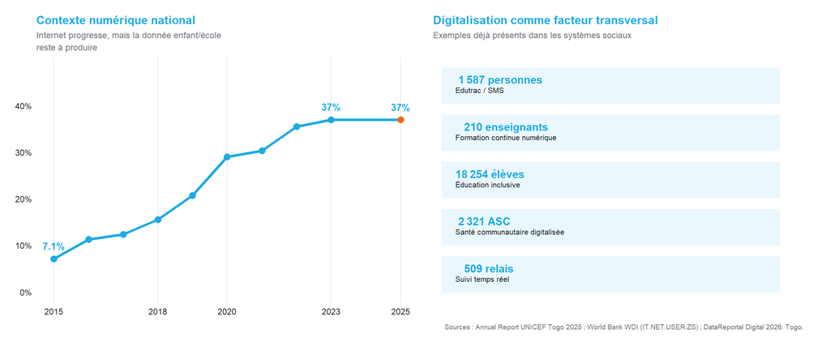

```r
# ---------- données panneau droit ----------

df_actions <- actions_digitales |>
  mutate(
    ordre     = factor(ordre, levels = rev(sort(unique(ordre)))),
    label_num = paste0(
      format(valeur, big.mark = "\u202f", decimal.mark = ","),
      " ", unite
    )
  )

# ---------- panneau gauche : courbe Internet ----------

p_digital_curve <- ggplot(digital, aes(x = annee, y = valeur)) +
  geom_line(colour = pal$blue, linewidth = 1.4) +
  geom_point(aes(colour = source), size = 3, show.legend = FALSE) +
  geom_text(
    data = digital |> filter(annee %in% c(2015, 2023, 2025)),
    aes(label = paste0(round(valeur, 1), "%")),
    vjust = -1.2, fontface = "bold",
    colour = pal$blue, size = 3.5, family = "sans"
  ) +
scale_colour_manual(
    values = c(
      "World Bank WDI IT.NET.USER.ZS"   = pal$blue,
      "DataReportal Digital 2026: Togo"  = pal$orange
    )
  ) +
  scale_y_continuous(
    limits = c(0, 48), breaks = seq(0, 40, 10),
    labels = label_percent(scale = 1)
  ) +
  scale_x_continuous(breaks = c(2015, 2018, 2020, 2023, 2025)) +
  labs(
    title    = "Contexte num\u00e9rique national",
    subtitle = "Internet progresse, mais la donn\u00e9e enfant/\u00e9cole\nreste \u00e0 produire",
    x = NULL, y = NULL
  ) +
  theme_unicef() +
  theme(
    legend.position = "none",
    plot.title    = element_text(colour = pal$blue, face = "bold", size = 12),
    plot.subtitle = element_text(colour = pal$gray, size = 9, lineheight = 1.2)
  )

# ---------- panneau droit : dispositifs (layout 2 lignes par bandeau) ----------

p_actions <- ggplot(df_actions, aes(x = 1, y = ordre)) +

  # Fond de bandeau
  geom_tile(
    width = 0.92, height = 0.82,
    fill = pal$light_blue, colour = "white", linewidth = 1.2
  ) +

  # Ligne 1 : chiffre + unité (gras, couleur blue)
  geom_text(
    aes(label = label_num),
    x = 0.58, vjust = -0.3,
    colour = pal$blue, fontface = "bold",
    size = 4.0, hjust = 0, family = "sans"
  ) +

  # Ligne 2 : nom du dispositif (sous le chiffre)
  geom_text(
    aes(label = dispositif),
    x = 0.58, vjust = 1.2,
    colour = pal$dark, fontface = "plain",
    size = 2.8, hjust = 0, lineheight = 0.9, family = "sans"
  ) +

  scale_x_continuous(limits = c(0.52, 1.55), expand = c(0, 0)) +
  labs(
    title    = "Digitalisation comme facteur transversal",
    subtitle = "Exemples d\u00e9j\u00e0 pr\u00e9sents dans les syst\u00e8mes sociaux",
    x = NULL, y = NULL,
    caption  = paste(
      "Sources : Annual Report UNICEF Togo 2025 ;",
      "World Bank WDI (IT.NET.USER.ZS) ;",
      "DataReportal Digital 2026: Togo."
    )
  ) +
  theme_unicef() +
  theme(
    axis.text    = element_blank(),
    axis.ticks   = element_blank(),
    panel.grid   = element_blank(),
    plot.title    = element_text(colour = pal$blue, face = "bold", size = 12),
    plot.subtitle = element_text(colour = pal$gray, size = 9, lineheight = 1.2),
    plot.caption  = element_text(hjust = 0.5, size = 7, colour = pal$gray,
                                 lineheight = 1.1, margin = margin(t = 8))
  )

# ---------- assemblage ----------

p_digital <- p_digital_curve | p_actions
p_digital
```

##bis Digitalisation : contexte national + dispositifs sectoriels — Vue synthétique bi-axes (infrastructure × usages)

Cette variante propose une matrice conceptuelle 2×2. Données hardcodées, à partir des csv du dossier data, vraissemblables, mais non réels

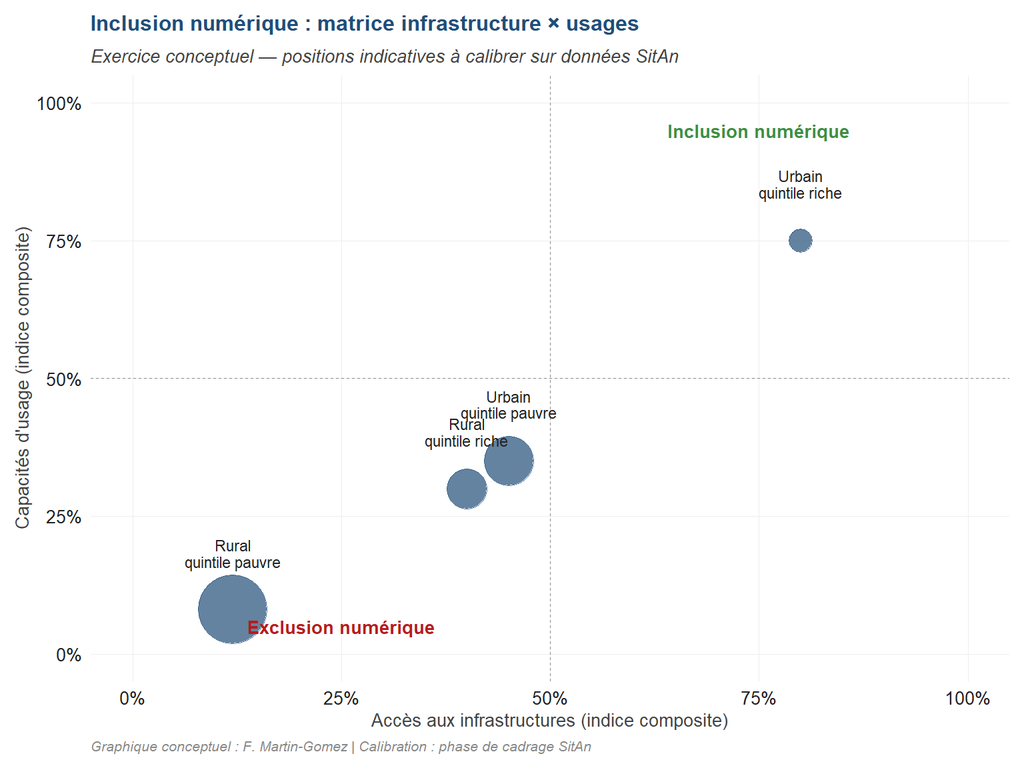

```r
# Positions indicatives (exercice conceptuel — à calibrer sur données réelles)
df_matrice <- tibble(
  groupe          = c("Urbain\nquintile riche",
                      "Urbain\nquintile pauvre",
                      "Rural\nquintile riche",
                      "Rural\nquintile pauvre"),
  infrastructure  = c(0.80, 0.45, 0.40, 0.12),
  usage           = c(0.75, 0.35, 0.30, 0.08),
  # Taille de la bulle ~ poids démographique indicatif
  poids_demo      = c(1.0, 1.5, 1.2, 2.5)
)

variante_b <- ggplot(df_matrice,
                     aes(x = infrastructure, y = usage,
                         size = poids_demo, label = groupe)) +
  geom_hline(yintercept = 0.5, linetype = "dashed",
             colour = pal_sitan$gray, linewidth = 0.3) +
  geom_vline(xintercept = 0.5, linetype = "dashed",
             colour = pal_sitan$gray, linewidth = 0.3) +
  geom_point(alpha = 0.7, colour = pal_sitan$head) +
  geom_text(size = 3, vjust = -1.5, lineheight = 0.9,
            colour = pal_sitan$text_main) +
  scale_size_continuous(range = c(6, 18)) +
  scale_x_continuous(labels = percent_format(accuracy = 1),
                     limits = c(0, 1)) +
  scale_y_continuous(labels = percent_format(accuracy = 1),
                     limits = c(0, 1)) +
  annotate("text", x = 0.75, y = 0.95, label = "Inclusion numérique",
           fontface = "bold", colour = pal_sitan$green, size = 3.5,
           family = base_family_default) +
  annotate("text", x = 0.25, y = 0.05, label = "Exclusion numérique",
           fontface = "bold", colour = pal_sitan$red, size = 3.5,
           family = base_family_default) +
  labs(
    title    = "Inclusion numérique : matrice infrastructure × usages",
    subtitle = "Exercice conceptuel — positions indicatives à calibrer sur données SitAn",
    x        = "Accès aux infrastructures (indice composite)",
    y        = "Capacités d'usage (indice composite)",
    caption  = "Graphique conceptuel : F. Martin-Gomez | Calibration : phase de cadrage SitAn"
  ) +
  theme_sitan(base_size = 11)

variante_b
```

```r
ggsave(here::here("projects", "SitAn-Togo", "output", "variante_B_matrice.png"),
       variante_b, width = 8, height = 6, dpi = 200, bg = "white", type = "cairo")
```

## 2.7 2.7 Bandeau analytique

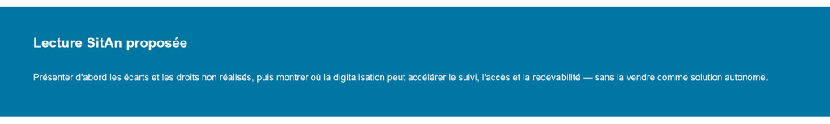

```r
p_reco <- ggplot() +
  geom_tile(aes(x = 0.5, y = 0.5), width = 1, height = 0.88,
            fill = pal$dark_blue) +
  annotate(
    "text", x = 0.04, y = 0.66, hjust = 0,
    label  = "Lecture SitAn propos\u00e9e",
    colour = "white", fontface = "bold", size = 5, family = "sans"
  ) +
  annotate(
    "text", x = 0.04, y = 0.38, hjust = 0,
    label  = paste(
      "Pr\u00e9senter d'abord les \u00e9carts et les droits non r\u00e9alis\u00e9s,",
      "puis montrer o\u00f9 la digitalisation peut acc\u00e9l\u00e9rer le suivi,",
      "l'acc\u00e8s et la redevabilit\u00e9 \u2014",
      "sans la vendre comme solution autonome."
    ),
    colour = "white", size = 3.4, family = "sans"
  ) +
  scale_x_continuous(limits = c(0, 1), expand = c(0, 0)) +
  scale_y_continuous(limits = c(0, 1), expand = c(0, 0)) +
  theme_void()

p_reco
```

## 2.8 Genre : l’écart qui structure toutes les autres inégalités

[figure not shown]

```r
# ---------- données ----------

genre <- read_csv(file.path(data_dir, "06_genre_digital_divide_togo.csv"),
                  show_col_types = FALSE)

# Sélection des indicateurs pour le dumbbell : paires F/H sur le Togo
df_dumbbell <- genre |>
  filter(
    perimetre == "Togo",
    sexe %in% c("femme", "homme"),
    indicateur %in% c(
      "Esp\u00e9rance de vie \u00e0 la naissance",
      "Ann\u00e9es de scolarisation attendues",
      "Ann\u00e9es moyennes de scolarisation (25+)",
      "RNB estim\u00e9 par habitant",
      "Possession t\u00e9l\u00e9phone mobile (10+)",
      "Audience Instagram",
      "Audience LinkedIn"
    )
  ) |>
  filter(!is.na(valeur)) |>
  select(indicateur, dimension, sexe, valeur, unite) |>
  pivot_wider(names_from = sexe, values_from = valeur) |>
  mutate(
    femme = as.numeric(femme),
    homme = as.numeric(homme)
  ) |>
  filter(!is.na(femme), !is.na(homme)) |>
  mutate(
    ecart     = homme - femme,
    ecart_pct = if_else(homme != 0, round((homme - femme) / homme * 100, 0), NA_real_),
    label_gap = case_when(
      unite == "USD PPA 2021" ~ paste0("\u2212", format(round(ecart), big.mark = "\u202f"), " $"),
      unite == "ann\u00e9es"  ~ paste0("\u2212", fr_num(ecart), " ans"),
      unite %in% c("% population 10+", "% audience adulte", "% audience") ~
        paste0("\u2212", round(ecart, 0), " pts"),
      TRUE ~ paste0("\u2212", fr_num(ecart))
    )
  )

# Ordre visuel : du plus structurel au plus digital
ordre_indicateurs <- c(
  "RNB estim\u00e9 par habitant",
  "Ann\u00e9es moyennes de scolarisation (25+)",
  "Ann\u00e9es de scolarisation attendues",
  "Esp\u00e9rance de vie \u00e0 la naissance",
  "Possession t\u00e9l\u00e9phone mobile (10+)",
  "Audience LinkedIn",
  "Audience Instagram"
)

# Labels courts pour l'axe Y
labels_courts <- c(
  "RNB estim\u00e9 par habitant"              = "Revenu estim\u00e9 (USD PPA)",
  "Ann\u00e9es moyennes de scolarisation (25+)" = "Scolarisation moyenne (25+)",
  "Ann\u00e9es de scolarisation attendues"      = "Scolarisation attendue",
  "Esp\u00e9rance de vie \u00e0 la naissance"   = "Esp\u00e9rance de vie",
  "Possession t\u00e9l\u00e9phone mobile (10+)" = "Possession mobile (10+)",
  "Audience LinkedIn"                            = "Audience LinkedIn",
  "Audience Instagram"                           = "Audience Instagram"
)

# Couleurs par dimension
couleur_dimension <- c(
  "sant\u00e9"         = pal$green,
  "\u00e9ducation"     = pal$blue,
  "revenu"             = pal$orange,
  "digital"            = pal$purple,
  "digital_pro"        = pal$dark_blue,
  "digital_social"     = pal$yellow
)

df_dumbbell <- df_dumbbell |>
  filter(indicateur %in% ordre_indicateurs) |>
  mutate(
    indicateur  = factor(indicateur, levels = rev(ordre_indicateurs)),
    label_court = labels_courts[as.character(indicateur)]
  )

# ---------- normalisation pour axe commun ----------
# Les indicateurs ont des unités très différentes (années, USD, %).
# On normalise chaque paire F/H en % du maximum homme pour un axe 0-100.

df_plot <- df_dumbbell |>
  mutate(
    max_val    = pmax(femme, homme),
    femme_norm = femme / max_val * 100,
    homme_norm = homme / max_val * 100
  )

# ---------- plot ----------

p_genre <- ggplot(df_plot, aes(y = indicateur)) +

  # Segment d'écart (fond large, clair)
  geom_segment(
    aes(x = femme_norm, xend = homme_norm,
        y = indicateur, yend = indicateur,
        colour = dimension),
    linewidth = 8, lineend = "round", alpha = 0.18
  ) +

  # Segment d'écart (trait fin)
  geom_segment(
    aes(x = femme_norm, xend = homme_norm,
        y = indicateur, yend = indicateur,
        colour = dimension),
    linewidth = 2.2, lineend = "round"
  ) +

  # Point femme
  geom_point(
    aes(x = femme_norm, fill = dimension),
    shape = 21, size = 10, colour = "white", stroke = 1.2
  ) +
  geom_text(
    aes(x = femme_norm, label = "F"),
    colour = "white", fontface = "bold", size = 3.5, family = "sans"
  ) +

  # Point homme
  geom_point(
    aes(x = homme_norm, fill = dimension),
    shape = 21, size = 10, colour = "white", stroke = 1.2
  ) +
  geom_text(
    aes(x = homme_norm, label = "H"),
    colour = "white", fontface = "bold", size = 3.5, family = "sans"
  ) +

  # Label écart au centre
  geom_label(
    aes(x = (femme_norm + homme_norm) / 2,
        y = indicateur,
        label = label_gap,
        colour = dimension),
    fill       = "white",
    fontface   = "bold",
    label.size = 0,
    size       = 3.0,
    family     = "sans",
    nudge_y    = 0.35
  ) +

  # Valeurs brutes sous les points
  geom_text(
    aes(x = femme_norm,
        label = case_when(
          unite == "USD PPA 2021" ~ paste0(format(round(femme), big.mark = "\u202f"), " $"),
          unite == "ann\u00e9es"  ~ paste0(fr_num(femme), " ans"),
          TRUE                    ~ paste0(round(femme, 1), "%")
        )),
    nudge_y = -0.30, colour = pal$gray, size = 2.6, family = "sans"
  ) +
  geom_text(
    aes(x = homme_norm,
        label = case_when(
          unite == "USD PPA 2021" ~ paste0(format(round(homme), big.mark = "\u202f"), " $"),
          unite == "ann\u00e9es"  ~ paste0(fr_num(homme), " ans"),
          TRUE                    ~ paste0(round(homme, 1), "%")
        )),
    nudge_y = -0.30, colour = pal$gray, size = 2.6, family = "sans"
  ) +

  # ---------- échelles ----------

  scale_y_discrete(labels = labels_courts) +
  scale_x_continuous(
    limits = c(30, 108), expand = c(0, 0),
    breaks = c(50, 75, 100),
    labels = c("50%", "75%", "100%")
  ) +
  scale_fill_manual(values = couleur_dimension) +
  scale_colour_manual(values = couleur_dimension) +

  # ---------- habillage ----------

  labs(
    title    = "Genre : l'\u00e9cart qui structure toutes les autres in\u00e9galit\u00e9s",
    subtitle = paste(
      "Chaque indicateur est normalis\u00e9 en % du maximum (H) pour",
      "permettre la comparaison visuelle \u2014 F = Femme, H = Homme"
    ),
    x = NULL, y = NULL,
    caption  = paste(
      "Sources : UNDP HDR 2025 (GDI Table, donn\u00e9es 2023) ;",
      "ITU Facts and Figures 2024 ;",
      "DataReportal Digital 2026: Togo ;",
      "Annuaire statistiques scolaires 2024-2025."
    )
  ) +
  theme_unicef() +
  theme(
    legend.position    = "none",
    panel.grid.major.x = element_line(colour = "#E6ECEF", linewidth = 0.4),
    panel.grid.major.y = element_blank(),
    axis.text.y        = element_text(face = "bold", colour = pal$dark, size = 10),
    plot.title          = element_text(face = "bold", colour = pal$blue, size = 16),
    plot.subtitle       = element_text(colour = pal$gray, size = 9, lineheight = 1.2),
    plot.caption        = element_text(colour = pal$gray, size = 7, hjust = 0,
                                       lineheight = 1.1)
  )

p_genre
```

##bis Genre : radar comparatif Femmes / Hommes

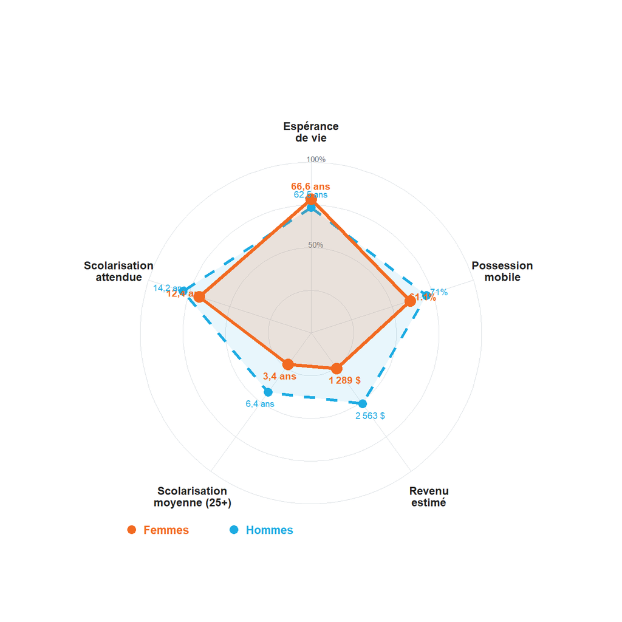

```r
# ---------- données ----------

df_radar_raw <- genre |>
  filter(
    perimetre == "Togo",
    sexe %in% c("femme", "homme"),
    indicateur %in% c(
      "Esp\u00e9rance de vie \u00e0 la naissance",
      "Ann\u00e9es de scolarisation attendues",
      "Ann\u00e9es moyennes de scolarisation (25+)",
      "RNB estim\u00e9 par habitant",
      "Possession t\u00e9l\u00e9phone mobile (10+)"
    )
  ) |>
  filter(!is.na(valeur)) |>
  select(indicateur, sexe, valeur) |>
  mutate(valeur = as.numeric(valeur))

# Labels courts
labels_radar <- c(
  "Esp\u00e9rance de vie \u00e0 la naissance"     = "Esp\u00e9rance\nde vie",
  "Ann\u00e9es de scolarisation attendues"         = "Scolarisation\nattendue",
  "Ann\u00e9es moyennes de scolarisation (25+)"    = "Scolarisation\nmoyenne (25+)",
  "RNB estim\u00e9 par habitant"                   = "Revenu\nestim\u00e9",
  "Possession t\u00e9l\u00e9phone mobile (10+)"    = "Possession\nmobile"
)

# Maximums de référence pour normalisation (bornes UNDP ou 100 % pour les %)
max_ref <- c(
  "Esp\u00e9rance de vie \u00e0 la naissance"     = 85,
  "Ann\u00e9es de scolarisation attendues"         = 18,
  "Ann\u00e9es moyennes de scolarisation (25+)"    = 15,
  "RNB estim\u00e9 par habitant"                   = 5000,
  "Possession t\u00e9l\u00e9phone mobile (10+)"    = 100
)

# Normaliser 0-1
df_radar <- df_radar_raw |>
  mutate(
    max_val = max_ref[indicateur],
    norm    = pmin(valeur / max_val, 1)
  )

# Ordre des axes (horaire, en partant du haut)
ordre_axes <- c(
  "Esp\u00e9rance de vie \u00e0 la naissance",
  "Ann\u00e9es de scolarisation attendues",
  "Ann\u00e9es moyennes de scolarisation (25+)",
  "RNB estim\u00e9 par habitant",
  "Possession t\u00e9l\u00e9phone mobile (10+)"
)

n_axes <- length(ordre_axes)

df_radar <- df_radar |>
  mutate(
    axe_idx = match(indicateur, ordre_axes),
    angle   = (axe_idx - 1) * 2 * pi / n_axes + pi / 2,
    x       = norm * cos(angle),
    y       = norm * sin(angle)
  )

# Fermer le polygone (dupliquer le premier point à la fin)
df_poly <- df_radar |>
  group_by(sexe) |>
  arrange(axe_idx) |>
  group_modify(~ bind_rows(.x, .x |> slice(1))) |>
  ungroup()

# ---------- grille de fond ----------

# Cercles concentriques
grille_niveaux <- c(0.25, 0.50, 0.75, 1.00)
df_cercles <- map_dfr(grille_niveaux, \(r) {
  tibble(
    theta = seq(0, 2 * pi, length.out = 120),
    x     = r * cos(theta + pi / 2),
    y     = r * sin(theta + pi / 2),
    r     = r
  )
})

# Rayons (axes)
df_rayons <- tibble(
  axe_idx = 1:n_axes,
  angle   = (axe_idx - 1) * 2 * pi / n_axes + pi / 2,
  xend    = cos(angle),
  yend    = sin(angle)
)

# Labels d'axes
df_labels <- df_rayons |>
  mutate(
    xl    = 1.18 * cos(angle),
    yl    = 1.18 * sin(angle),
    label = labels_radar[ordre_axes[axe_idx]]
  )

# Labels des valeurs brutes sur chaque axe
df_val_labels <- df_radar |>
  mutate(
    xl = (norm + 0.08) * cos(angle),
    yl = (norm + 0.08) * sin(angle),
    val_label = case_when(
      indicateur == "RNB estim\u00e9 par habitant" ~
        paste0(format(round(valeur), big.mark = "\u202f"), " $"),
      indicateur == "Possession t\u00e9l\u00e9phone mobile (10+)" ~
        paste0(round(valeur, 1), "%"),
      TRUE ~ paste0(fr_num(valeur), " ans")
    )
  )

# ---------- plot ----------

p_radar <- ggplot() +

  # Cercles concentriques
  geom_path(
    data = df_cercles,
    aes(x = x, y = y, group = r),
    colour    = "#D9DEE2",
    linewidth = 0.3
  ) +

  # Rayons
  geom_segment(
    data = df_rayons,
    aes(x = 0, y = 0, xend = xend, yend = yend),
    colour    = "#D9DEE2",
    linewidth = 0.3
  ) +

  # Labels % sur le cercle 50 % et 100 %
  annotate(
    "text", x = 0.03, y = 0.52,
    label = "50%", colour = pal$gray, size = 2.3, family = "sans"
  ) +
  annotate(
    "text", x = 0.03, y = 1.02,
    label = "100%", colour = pal$gray, size = 2.3, family = "sans"
  ) +

  # Polygone HOMME (fond + contour)
  geom_polygon(
    data = df_poly |> filter(sexe == "homme"),
    aes(x = x, y = y),
    fill = pal$blue, alpha = 0.10,
    colour = pal$blue, linewidth = 1.2, linetype = "dashed"
  ) +

  # Polygone FEMME (fond + contour)
  geom_polygon(
    data = df_poly |> filter(sexe == "femme"),
    aes(x = x, y = y),
    fill = pal$orange, alpha = 0.15,
    colour = pal$orange, linewidth = 1.4
  ) +

  # Points sur les sommets
  geom_point(
    data = df_radar |> filter(sexe == "homme"),
    aes(x = x, y = y),
    colour = pal$blue, size = 3, shape = 16
  ) +
  geom_point(
    data = df_radar |> filter(sexe == "femme"),
    aes(x = x, y = y),
    colour = pal$orange, size = 4, shape = 16
  ) +

  # Valeurs brutes à côté des points
  geom_text(
    data = df_val_labels |> filter(sexe == "femme"),
    aes(x = xl, y = yl, label = val_label),
    colour = pal$orange, fontface = "bold", size = 2.8, family = "sans"
  ) +
  geom_text(
    data = df_val_labels |> filter(sexe == "homme"),
    aes(x = xl, y = yl, label = val_label),
    colour = pal$blue, size = 2.5, family = "sans"
  ) +

  # Labels des axes
  geom_text(
    data = df_labels,
    aes(x = xl, y = yl, label = label),
    colour     = pal$dark,
    fontface   = "bold",
    size       = 3.2,
    lineheight = 0.85,
    family     = "sans"
  ) +

  # Légende manuelle
  annotate(
    "point", x = -1.05, y = -1.15,
    colour = pal$orange, size = 3, shape = 16
  ) +
  annotate(
    "text", x = -0.98, y = -1.15, hjust = 0,
    label = "Femmes", colour = pal$orange, fontface = "bold",
    size = 3.3, family = "sans"
  ) +
  annotate(
    "point", x = -0.45, y = -1.15,
    colour = pal$blue, size = 3, shape = 16
  ) +
  annotate(
    "text", x = -0.38, y = -1.15, hjust = 0,
    label = "Hommes", colour = pal$blue, fontface = "bold",
    size = 3.3, family = "sans"
  ) +

  # ---------- coord & habillage ----------

  coord_equal(clip = "off") +
  scale_x_continuous(limits = c(-1.45, 1.45)) +
  scale_y_continuous(limits = c(-1.35, 1.45)) +

  labs(
    title    = "",
    subtitle = paste(
      "",
      ""
    ),
    caption  = paste(
      "",
      "",
      "",
      ""
    )
  ) +
  theme_void() +
  theme(
    plot.title    = element_text(face = "bold", colour = pal$blue, size = 16,
                                 hjust = 0.5, margin = margin(b = 4)),
    plot.subtitle = element_text(colour = pal$gray, size = 9, hjust = 0.5,
                                 lineheight = 1.2, margin = margin(b = 12)),
    plot.caption  = element_text(colour = pal$gray, size = 6.5, hjust = 0.5,
                                 lineheight = 1.1, margin = margin(t = 12)),
    plot.margin   = margin(10, 10, 10, 10)
  )

p_radar
```

# 3 Assemblage final

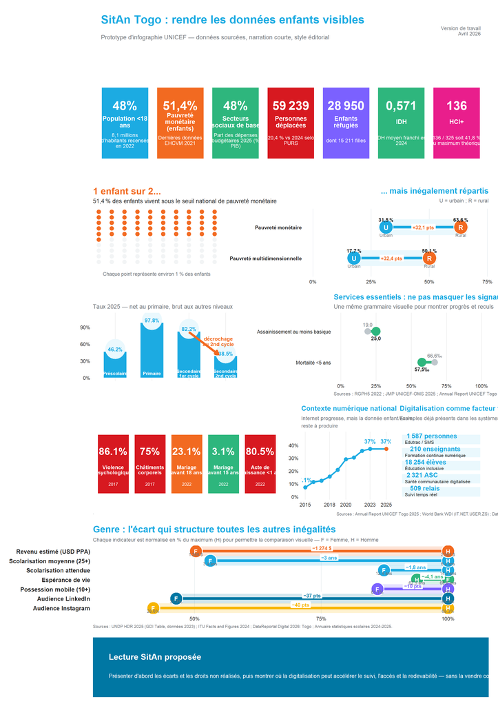

```r
titre <- ggplot() +
  annotate(
    "text", x = 0.02, y = 0.72, hjust = 0,
    label  = "SitAn Togo : rendre les donn\u00e9es enfants visibles",
    colour = pal$blue, fontface = "bold", size = 7, family = "sans"
  ) +
  annotate(
    "text", x = 0.02, y = 0.38, hjust = 0,
    label  = paste(
      "Prototype d'infographie UNICEF \u2014 donn\u00e9es sourc\u00e9es,",
      "narration courte, style \u00e9ditorial"
    ),
    colour = pal$gray, size = 3.7, family = "sans"
  ) +
  annotate(
    "text", x = 0.98, y = 0.50, hjust = 1,
    label  = "Version de travail\nAvril 2026",
    colour = pal$gray, size = 3.1, lineheight = 0.9, family = "sans"
  ) +
  scale_x_continuous(limits = c(0, 1), expand = c(0, 0)) +
  scale_y_continuous(limits = c(0, 1), expand = c(0, 0)) +
  theme_void()

dashboard <- (
  titre /
  p_cards /
  (
    p_poverty /
    (p_education | p_wash) /
    (p_protection | p_digital) /
    p_genre/
    p_reco
  )
) +
  plot_layout(heights = c(0.55, 0.9, 5.2))

dashboard
```

# 4 Export

```r
# ---------- panneaux individuels ----------

plots_individuels <- list(
  "01_keyfigures"  = list(plot = p_cards,      w = 14,   h = 3.6),
  "02_poverty"     = list(plot = p_poverty,     w = 8.2,  h = 4.8),
  "03_education"   = list(plot = p_education,   w = 6.5,  h = 4.8),
  "04_wash_health" = list(plot = p_wash,        w = 8.5,  h = 4.8),
  "05_protection"  = list(plot = p_protection,  w = 6.5,  h = 4.8),
  "06_digital"     = list(plot = p_digital,     w = 12,   h = 5),
  "07_reco"        = list(plot = p_reco,        w = 12,   h = 1.8),
  "08_genre"     = list(plot = p_genre,     w = 10,   h = 6.5),
  "09_radar"     = list(plot = p_radar,     w = 10,   h = 6.5)
)

iwalk(plots_individuels, \(spec, nom) {
  ggsave(
    filename = file.path(output_dir, paste0(nom, ".png")),
    plot     = spec$plot,
    width    = spec$w,
    height   = spec$h,
    units    = "in",
    dpi      = 220,
    bg       = "white"
  )
})

message(
  "Export panneaux individuels : ",
  paste(names(plots_individuels), collapse = ", ")
)

# ---------- dashboard assemblé ----------

ggsave(
  filename = file.path(output_dir, "infographie_sitan_togo_unicef_style.png"),
  plot     = dashboard,
  width    = 12,
  height   = 17,
  units    = "in",
  dpi      = 220,
  bg       = "white"
)

ggsave(
  filename = file.path(output_dir, "infographie_sitan_togo_unicef_style.pdf"),
  plot     = dashboard,
  width    = 12,
  height   = 17,
  units    = "in",
  bg       = "white"
)

message("Export termin\u00e9 : 7 panneaux PNG + dashboard PNG/PDF dans output/")
```

## 4.1 5. Notes méthodologiques

- Les chiffres de pauvreté, d’éducation, WASH, santé et protection sont repris du rapport annuel UNICEF Togo 2025 et/ou des TdR SitAn 2026.
- Les chiffres numériques nationaux sont des indicateurs de contexte : ils ne remplacent pas une mesure d’accès numérique des enfants, des ménages avec enfants ou des écoles.
- Les valeurs issues de sources anciennes, notamment MICS6 2017 et PASEC 2019, sont volontairement visibles : elles signalent la priorité de mise à jour statistique.
- Cette version évite les faux indicateurs et remplace les proxys les plus fragiles du notebook initial par des données documentées.

## 4.2 6. Prochaines extensions utiles

1. Ajouter une page par cycle de vie : petite enfance, 5–11 ans, 12–18 ans.
2. Extraire les désagrégations régionales depuis l’annuaire scolaire et le RGPH5.
3. Remplacer la courbe de connectivité nationale par des indicateurs enfants/écoles dès que les données MICS7, SIGE, Giga ou enquête TIC-ménages sont disponibles.
4. Produire une version “children and adolescents friendly” avec moins de texte et plus de pictogrammes.

# 5 Autres analyses et infographies non présentées dans la note de déminstration

## 5.1 Fracture numérique globale

```r
df_fracture <- read_csv(
  here::here("projects", "SitAn-Togo", "data_sitan_togo", "01_fracture_globale.csv"),
  comment = "#",
  show_col_types = FALSE
) |>
  mutate(
    zone = fct_reorder(zone, ordre),
    etiquette = paste0(valeur, "%")
  )

df_fracture
```

```
# A tibble: 4 × 5
  zone                  valeur ordre categorie   etiquette
  <fct>                  <dbl> <dbl> <chr>       <chr>
1 Urbain mondial            40     4 mondial     40%
2 Rural mondial             25     3 mondial     25%
3 Afrique subsaharienne     13     2 subsaharien 13%
4 Togo* (estimé)            10     1 togo_proxy  10%
```

**Source** : UNICEF–ITU (2020), *How Many Children and Youth Have Internet Access at Home?*. Estimation Togo : extrapolation à partir de la moyenne pour les LDCs subsahariens. **À actualiser** en phase de cadrage via MICS7 ou enquête TIC-ménages.

## 5.2 Inégalités intra-Togo (proxy pauvreté multidimensionnelle)

```r
df_inegalites <- read_csv(
  here::here("projects", "SitAn-Togo", "data_sitan_togo", "02_inegalites_togo.csv"),
  comment = "#",
  show_col_types = FALSE
) |>
  mutate(
    groupe = fct_reorder(groupe, ordre),
    etiquette = paste0(valeur, "%")
  )

df_inegalites
```

```
# A tibble: 6 × 5
  groupe          valeur axe      ordre etiquette
  <fct>            <dbl> <chr>    <dbl> <chr>
1 Urbain            17.7 milieu       1 17.7%
2 Rural             50.1 milieu       2 50.1%
3 Quintile riche    12   richesse     3 12%
4 Quintile pauvre   78   richesse     4 78%
5 Filles            53   sexe         5 53%
6 Garçons           49   sexe         6 49%
```

## 5.3 Conditions habilitantes dans les écoles

```r
df_wash <- read_csv(
  here::here("projects", "SitAn-Togo", "data_sitan_togo", "03_wash_ecoles.csv"),
  comment = "#",
  show_col_types = FALSE
) |>
  mutate(
    indicateur_wrap = str_wrap(indicateur, width = 12),
    indicateur_wrap = fct_inorder(indicateur_wrap),
    etiquette = paste0(valeur, "%")
  )

df_wash
```

```
# A tibble: 5 × 6
  indicateur           valeur type  alerte   indicateur_wrap         etiquette
  <chr>                 <dbl> <chr> <chr>    <fct>                   <chr>
1 Eau potable              62 wash  moyen    "Eau potable"           62%
2 Sanitaires               58 wash  moyen    "Sanitaires"            58%
3 Hygiène mains            50 wash  faible   "Hygiène\nmains"        50%
4 Paquet WASH complet      44 wash  faible   "Paquet WASH\ncomplet"  44%
5 Électricité (estim.)     35 elec  critique "Électricité\n(estim.)" 35%
```

**Source** : Annuaire des statistiques scolaires 2024-2025, Ministère de l’Éducation togolais (cité dans les TdR SitAn — paquet WASH complet : 44 %). Les valeurs désagrégées eau/sanitaires/hygiène et l’estimation électricité sont des valeurs de travail à consolider à partir de l’Annuaire intégral en phase de cadrage.

## 5.4 Timeline des initiatives numériques éducatives

```r
df_timeline <- read_csv(
  here::here("projects", "SitAn-Togo", "data_sitan_togo", "04_initiatives_timeline.csv"),
  comment = "#",
  show_col_types = FALSE
) |>
  mutate(rang = row_number())

df_timeline
```

```
# A tibble: 7 × 4
  annee nom              description                                      rang
  <dbl> <chr>            <chr>                                           <int>
1  2020 PSE 2020-2030    Stratégie sectorielle (>2 000 Mds FCFA)             1
2  2021 ENT déployé      Environnement Numérique de Travail (secondaire)     2
3  2022 Câble Equiano    Bande passante × 20 (Google fibre optique)          3
4  2023 DHIS2 éducation  Saisie nationale des résultats d'examens            4
5  2024 Tablettes DRE    Distribution aux directions régionales              5
6  2024 Chatbot WhatsApp Diffusion résultats examens (16 juin)               6
7  2026 Initiative GIGA  Connexion écoles (UNICEF–UIT) prévue                7
```

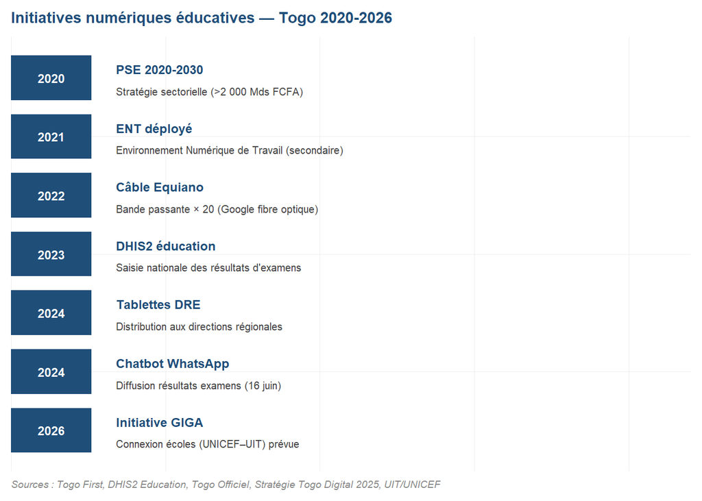

```r
#| fig-width: 5
#| fig-height: 3.5

# Construction "à la main" car c'est une timeline textuelle, pas un geom standard
df_timeline_plot <- df_timeline |>
  mutate(
    # y en ordre inverse pour que 2020 soit en haut
    y = max(rang) - rang + 1
  )

p4 <- ggplot(df_timeline_plot) +
  # Badge année (rectangle bleu foncé à gauche)
  geom_rect(aes(xmin = 0, xmax = 0.13,
                ymin = y - 0.38, ymax = y + 0.38),
            fill = pal_sitan$head) +
  # Année en blanc dans le badge
  geom_text(aes(x = 0.065, y = y, label = annee),
            colour = "white", fontface = "bold", size = 3,
            family = base_family_default) +
  # Nom de l'initiative
  geom_text(aes(x = 0.17, y = y + 0.15, label = nom),
            hjust = 0, fontface = "bold", size = 3.2,
            colour = pal_sitan$head, family = base_family_default) +
  # Description
  geom_text(aes(x = 0.17, y = y - 0.22, label = description),
            hjust = 0, size = 2.7, colour = pal_sitan$text_dim,
            family = base_family_default) +
  scale_x_continuous(limits = c(0, 1.1), expand = c(0, 0)) +
  scale_y_continuous(limits = c(0.3, max(df_timeline_plot$y) + 0.7),
                     expand = c(0, 0)) +
  labs(
    title   = "Initiatives numériques éducatives — Togo 2020-2026",
    x       = NULL,
    y       = NULL,
    caption = "Sources : Togo First, DHIS2 Education, Togo Officiel, Stratégie Togo Digital 2025, UIT/UNICEF"
  ) +
  theme_sitan(base_family = base_family_default) +
  theme(
    axis.text  = element_blank(),
    axis.ticks = element_blank(),
    panel.grid = element_blank()
  )

p4
```

```r
ggsave(here::here("projects", "SitAn-Togo", "output", "timleline_num.png"),
       p4, width = 5, height = 3.5, dpi = 200, bg = "white", type = "cairo")
```

**Sources** : Togo First (juin 2024), DHIS2 Education (juin 2024), République Togolaise, ATOP, Togo Réveil, Planipolis UNESCO, UIT–UNICEF (Initiative GIGA).

## 5.5 Alternative Panneaux : Fracture numérique globale

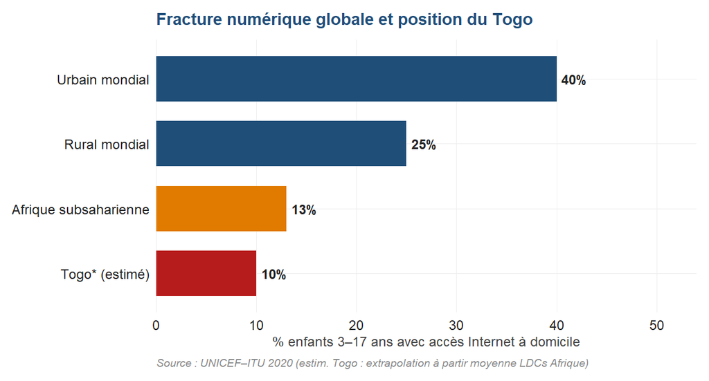

```r
# Palette manuelle reflétant la criticité par zone
pal_p1 <- c(
  "Urbain mondial"         = pal_sitan$head,
  "Rural mondial"          = pal_sitan$head,
  "Afrique subsaharienne"  = pal_sitan$orange,
  "Togo* (estimé)"         = pal_sitan$red
)

p1 <- ggplot(df_fracture, aes(x = valeur, y = zone, fill = zone)) +
  geom_col(width = 0.7) +
  geom_text(aes(label = etiquette),
            hjust = -0.2, fontface = "bold", size = 3.2,
            colour = pal_sitan$text_main) +
  scale_x_continuous(limits = c(0, 50), expand = expansion(mult = c(0, 0.08))) +
  scale_fill_manual(values = pal_p1) +
  labs(
    title   = "Fracture numérique globale et position du Togo",
    x       = "% enfants 3–17 ans avec accès Internet à domicile",
    y       = NULL,
    caption = "Source : UNICEF–ITU 2020 (estim. Togo : extrapolation à partir moyenne LDCs Afrique)"
  ) +
  theme_sitan()

p1
```

```r
ggsave(here::here("projects", "SitAn-Togo", "output", "alt_panneaux1.png"),
       p1, width = 6.5, height = 3.5, dpi = 200, bg = "white", type = "cairo")
```

## 5.6 Variante A — Visualisation comparative pays (lollipop)

Cette variante transforme le panneau 1 en lollipop chart plus lisible pour une note courte ou un billet de blog.

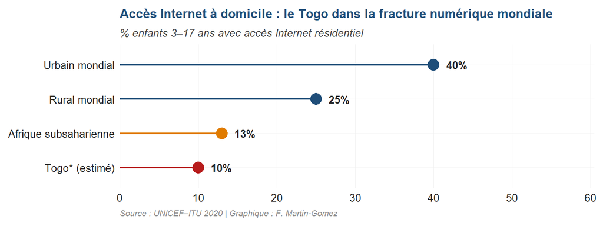

```r
variante_a <- ggplot(df_fracture, aes(x = valeur, y = zone, colour = zone)) +
  geom_segment(aes(x = 0, xend = valeur, yend = zone),
               linewidth = 0.8) +
  geom_point(size = 5) +
  geom_text(aes(label = etiquette),
            hjust = -0.6, fontface = "bold", size = 3.5,
            colour = pal_sitan$text_main) +
  scale_x_continuous(limits = c(0, 55), expand = expansion(mult = c(0, 0.1))) +
  scale_colour_manual(values = pal_p1) +
  labs(
    title    = "Accès Internet à domicile : le Togo dans la fracture numérique mondiale",
    subtitle = "% enfants 3–17 ans avec accès Internet résidentiel",
    x        = NULL, y = NULL,
    caption  = "Source : UNICEF–ITU 2020 | Graphique : F. Martin-Gomez"
  ) +
  theme_sitan(base_size = 11)

variante_a
```

```r
ggsave(here::here("projects", "SitAn-Togo", "output", "variante_A_lollipop.png"),
       variante_a, width = 7, height = 4, dpi = 200, bg = "white", type = "cairo")
```

## 5.7 Panneau 2 — Inégalités intra-Togo

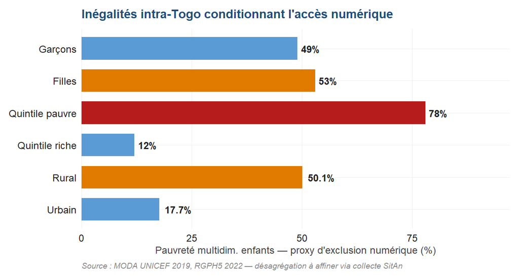

```r
# Palette dépendant de l'axe d'inégalité
pal_p2 <- c(
  "Urbain"           = pal_sitan$mid_blue,
  "Rural"            = pal_sitan$orange,
  "Quintile riche"   = pal_sitan$mid_blue,
  "Quintile pauvre"  = pal_sitan$red,
  "Filles"           = pal_sitan$orange,
  "Garçons"          = pal_sitan$mid_blue
)

p2 <- ggplot(df_inegalites, aes(x = valeur, y = groupe, fill = groupe)) +
  geom_col(width = 0.7) +
  geom_text(aes(label = etiquette),
            hjust = -0.2, fontface = "bold", size = 3.2,
            colour = pal_sitan$text_main) +
  scale_x_continuous(limits = c(0, 90), expand = expansion(mult = c(0, 0.08))) +
  scale_fill_manual(values = pal_p2) +
  labs(
    title   = "Inégalités intra-Togo conditionnant l'accès numérique",
    x       = "Pauvreté multidim. enfants — proxy d'exclusion numérique (%)",
    y       = NULL,
    caption = "Source : MODA UNICEF 2019, RGPH5 2022 — désagrégation à affiner via collecte SitAn"
  ) +
  theme_sitan()

p2
```

```r
ggsave(here::here("projects", "SitAn-Togo", "output", "inegalites_togo2.png"),
       p2, width = 6.5, height = 3.5, dpi = 200, bg = "white", type = "cairo")
```

## 5.8 Panneau 3 — Conditions habilitantes scolaires

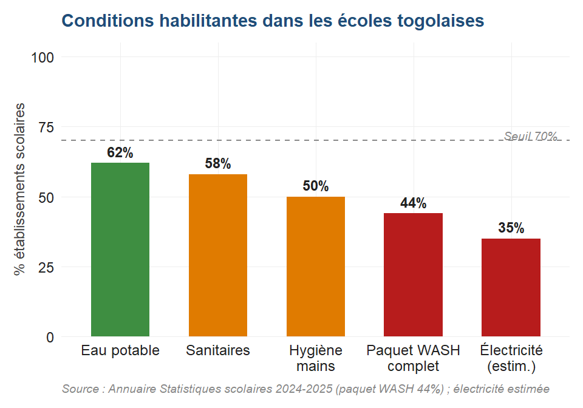

```r
# Couleurs par niveau de criticité
pal_p3 <- c(
  moyen    = pal_sitan$green,
  faible   = pal_sitan$orange,
  critique = pal_sitan$red
)

# Logique de coloration : ≥60 = vert, 45-60 = orange, <45 = rouge
df_wash_color <- df_wash |>
  mutate(
    niveau = case_when(
      valeur >= 60 ~ "moyen",
      valeur >= 45 ~ "faible",
      TRUE         ~ "critique"
    )
  )

p3 <- ggplot(df_wash_color, aes(x = indicateur_wrap, y = valeur, fill = niveau)) +
  geom_col(width = 0.6) +
  geom_text(aes(label = etiquette),
            vjust = -0.6, fontface = "bold", size = 3.2,
            colour = pal_sitan$text_main) +
  geom_hline(yintercept = 70, linetype = "dashed",
             colour = pal_sitan$gray, linewidth = 0.4) +
  annotate("text", x = 5.2, y = 72, label = "Seuil 70%",
           size = 2.5, fontface = "italic", colour = pal_sitan$gray,
           family = base_family_default) +
  scale_y_continuous(limits = c(0, 100), expand = expansion(mult = c(0, 0.05))) +
  scale_fill_manual(values = pal_p3) +
  labs(
    title   = "Conditions habilitantes dans les écoles togolaises",
    x       = NULL,
    y       = "% établissements scolaires",
    caption = "Source : Annuaire Statistiques scolaires 2024-2025 (paquet WASH 44%) ; électricité estimée"
  ) +
  theme_sitan()

p3
```

```r
ggsave(here::here("projects", "SitAn-Togo", "output", "condition_habilitantes-togo.png"),
       p3, width = 5, height = 3.5, dpi = 200, bg = "white", type = "cairo")
```

## 5.9 Quatre risques transversaux

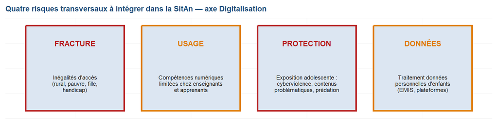

```r
# Données risques (inline — pas un "dataset" au sens plein)
df_risques <- tibble(
  titre   = c("FRACTURE", "USAGE", "PROTECTION", "DONNÉES"),
  texte   = c(
    "Inégalités d'accès\n(rural, pauvre, fille,\nhandicap)",
    "Compétences numériques\nlimitées chez enseignants\net apprenants",
    "Exposition adolescente :\ncyberviolence, contenus\nproblématiques, prédation",
    "Traitement données\npersonnelles d'enfants\n(EMIS, plateformes)"
  ),
  couleur = c(pal_sitan$red, pal_sitan$orange, pal_sitan$red, pal_sitan$orange),
  x       = 1:4
)

p5 <- ggplot(df_risques) +
  # Rectangles encadrés
  geom_tile(aes(x = x, y = 1, width = 0.85, height = 0.85),
            fill = pal_sitan$light, colour = NA) +
  # Bordure colorée par risque
  geom_rect(aes(xmin = x - 0.425, xmax = x + 0.425,
                ymin = 0.575, ymax = 1.425,
                colour = couleur),
            fill = NA, linewidth = 1.2) +
  # Titre du risque
  geom_text(aes(x = x, y = 1.25, label = titre, colour = couleur),
            fontface = "bold", size = 3.8, family = base_family_default) +
  # Description
  geom_text(aes(x = x, y = 0.85, label = texte),
            size = 2.9, colour = pal_sitan$text_main, lineheight = 0.9,
            family = base_family_default) +
  scale_colour_identity() +
  scale_x_continuous(limits = c(0.4, 4.6), expand = c(0, 0)) +
  scale_y_continuous(limits = c(0.5, 1.5), expand = c(0, 0)) +
  labs(title = "Quatre risques transversaux à intégrer dans la SitAn — axe Digitalisation") +
  theme_sitan(base_family = base_family_default) +
  theme(
    axis.text   = element_blank(),
    axis.title  = element_blank(),
    axis.ticks  = element_blank(),
    panel.grid  = element_blank()
  )

p5
```

```r
ggsave(here::here("projects", "SitAn-Togo", "output", "4risques_trans.png"),
       p3, width = 10, height = 2.5, dpi = 200, bg = "white", type = "cairo")
```

# 6 Traçabilité des proxys mobilisés (avec statut probatoire)

La colonne « Statut » qualifie chaque indicateur selon la typologie introduite dans la note : **[OBS]** donnée observée Togo · **[PRX]** proxy · **[REG]** comparaison régionale · **[HYP]** hypothèse à tester.

Traçabilité des indicateurs et de leur statut probatoire

[output not shown]

**Lecture du tableau.** Quatre statuts coexistent : les données **observées** au Togo récent (OBS) constituent le socle empirique solide ; les **proxys** (PRX) suppléent à des mesures directes manquantes mais doivent être confirmés ; les **comparaisons régionales** (REG) servent de points de référence ; les **hypothèses analytiques** (HYP) identifient les zones où la SitAn doit produire des données primaires nouvelles. Cette typologie préfigure une colonne dédiée du dictionnaire d’indicateurs complet qui serait produit en phase de cadrage.